# Ford GoBike System Data Investigation

## Investigation Overview

This presentation will answer the following questions:

- What are the top 5 frequent places for all users types?
- Which user type represents the bike riders in the most frequent places?
- Which user type takes a long time for a ride in the top 5 start stations and top 5 end stations?

## Dataset Overview

Ford GoBike is an electric bike let you go farther faster, and up hills. It's more popular in San Francisco since biking is the fastest growing mode of transportation there. Ford GoBike is expanding to the East Bay — in Oakland, Emeryville and Berkeley — and to San Jose in the South Bay.

```python
# import all packages and set plots to be embedded inline
import numpy as np
import pandas as pd
import matplotlib.pyplot as plt
import seaborn as sb

%matplotlib inline

# suppress warnings from final output
import warnings
warnings.simplefilter("ignore")
```

```python
# load in the dataset into a pandas dataframe
df = pd.read_csv('2017-fordgobike-tripdata.csv')
```

## Visualization 1

- What are the top 5 frequent places for all users types?

The top five frequent places in the start stations and the top five frequent places in the end stations most of them are in San Francisco as mentioned that biking is the fastest growing mode of transportation there.

```python
# data set up
start_name_count  = df['start_station_name'].value_counts()
start_name_count  = start_name_count[:5,]
base_color = sb.color_palette()[0]
```

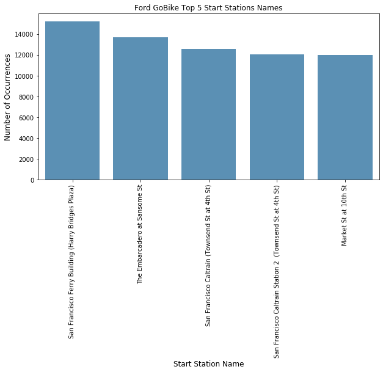

```python
# plotting
plt.figure(figsize=(10,5))
sb.barplot(start_name_count.index, start_name_count.values, alpha=0.8, color = base_color );
plt.title('Ford GoBike Top 5 Start Stations Names')
plt.ylabel('Number of Occurrences', fontsize=12)
plt.xlabel('Start Station Name', fontsize=12)
plt.xticks(rotation = 90);
plt.show();
```

```python
# data set up
end_name_count  = df['end_station_name'].value_counts()
end_name_count  = end_name_count[:5,]
```

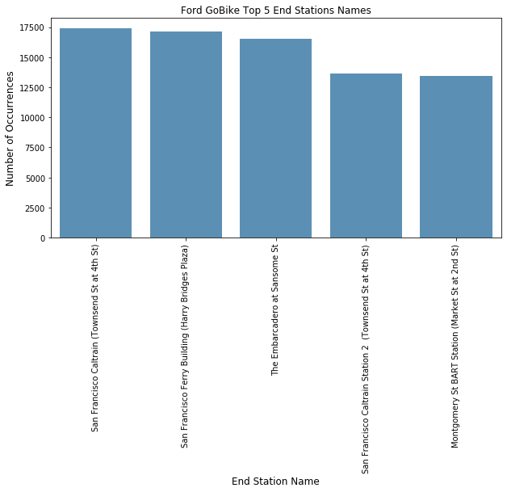

```python
# plotting
plt.figure(figsize=(10,5))
sb.barplot(end_name_count.index, end_name_count.values, alpha=0.8, color = base_color )
plt.title('Ford GoBike Top 5 End Stations Names')
plt.ylabel('Number of Occurrences', fontsize=12)
plt.xlabel('End Station Name', fontsize=12)
plt.xticks(rotation = 90);
plt.show();
```

## Visualization 2

- Which user type represents the bike riders in the most frequent places?

```python
# The first sub-set of the data
top5_start_df  = df.query('start_station_name in ["San Francisco Ferry Building (Harry Bridges Plaza)","The Embarcadero at Sansome St","San Francisco Caltrain (Townsend St at 4th St)","San Francisco Caltrain Station 2  (Townsend St at 4th St)","Market St at 10th St"]')
```

```python
# The second sub-set of the data
top5_end_df = df.query('end_station_name in ["San Francisco Caltrain (Townsend St at 4th St)","San Francisco Ferry Building (Harry Bridges Plaza)","The Embarcadero at Sansome St", "San Francisco Caltrain Station 2  (Townsend St at 4th St)","Montgomery St BART Station (Market St at 2nd St)"]')
```

```python
# data set up
df_start_counts = top5_start_df.groupby(['start_station_name','user_type']).size()
df_start_counts = df_start_counts.reset_index(name = 'count')
df_start_counts = df_start_counts.pivot(index = 'start_station_name', columns = 'user_type', values = 'count')
```

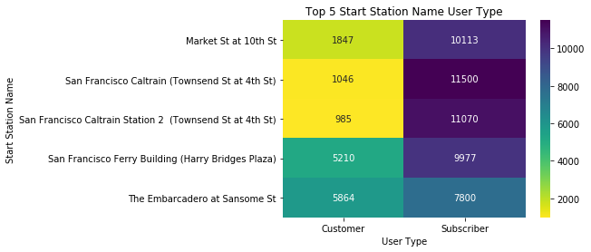

```python
# plotting
sb.heatmap(df_start_counts,annot = True, fmt = 'd', cmap = 'viridis_r');
plt.xlabel('User Type')
plt.ylabel('Start Station Name')
plt.title('Top 5 Start Station Name User Type');
```

```python
# data set up
df_end_counts = top5_end_df.groupby(['end_station_name','user_type']).size()
df_end_counts = df_end_counts.reset_index(name = 'count')
df_end_counts = df_end_counts.pivot(index = 'end_station_name', columns = 'user_type', values = 'count')
```

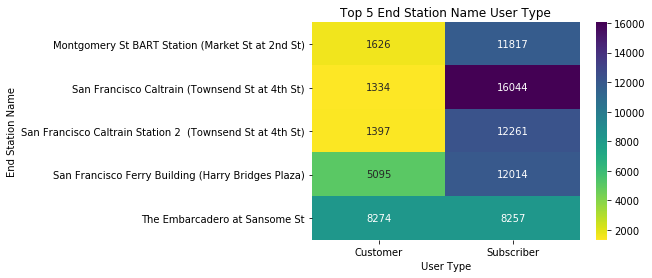

```python
# plotting
sb.heatmap(df_end_counts,annot = True, fmt = 'd', cmap = 'viridis_r');
plt.xlabel('User Type')
plt.ylabel('End Station Name')
plt.title('Top 5 End Station Name User Type');
```

## Visualization 3

- Which user type takes a long time for a ride in the top 5 start stations and top 5 end stations?

Although subscribers found to be the most frequent user type in the top five places for start stations and end stations, it is found that long ride durations are represented by customers. This explains that customers might be tourists who enjoy San Fransisco weather and views with a long time ride.

```python
# data set up
top5_st_duration_mean = top5_start_df.groupby(['start_station_name','user_type'])['duration_sec'].mean()
top5_st_duration_mean = top5_st_duration_mean.reset_index(name = 'count')
```

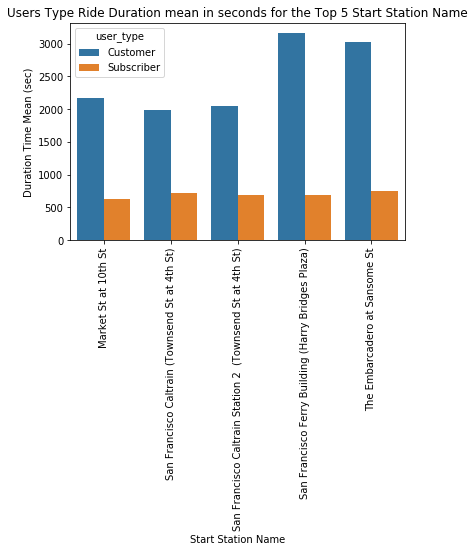

```python
# Plotting
sb.barplot(data = top5_st_duration_mean , x='start_station_name', y='count', hue= 'user_type');
plt.xticks(rotation = 90)
plt.ylabel('Duration Time Mean (sec)')
plt.xlabel('Start Station Name')
plt.title('Users Type Ride Duration mean in seconds for the Top 5 Start Station Name');
```

```python
# Data set up
top5_end_duration_mean = top5_end_df.groupby(['end_station_name','user_type'])['duration_sec'].mean()
top5_end_duration_mean = top5_end_duration_mean.reset_index(name = 'count')
```

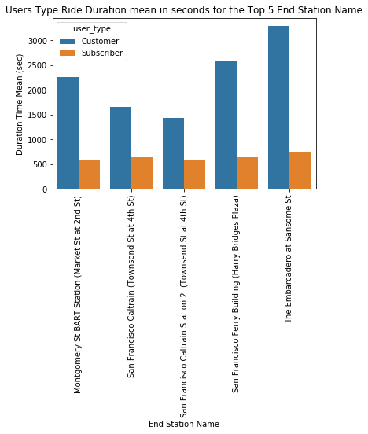

```python
# Plotting
sb.barplot(data = top5_end_duration_mean , x='end_station_name', y='count', hue= 'user_type');
plt.xticks(rotation = 90)
plt.ylabel('Duration Time Mean (sec)')
plt.xlabel('End Station Name')
plt.title('Users Type Ride Duration mean in seconds for the Top 5 End Station Name');
```

```python
!jupyter nbconvert slide_deck_template.ipynb --to slides --template output-toggle.tpl --post serve
```

```
[NbConvertApp] Converting notebook slide_deck_template.ipynb to slides
[NbConvertApp] Writing 507286 bytes to slide_deck_template.slides.html
[NbConvertApp] Redirecting reveal.js requests to https://cdnjs.cloudflare.com/ajax/libs/reveal.js/3.5.0
Serving your slides at http://127.0.0.1:8000/slide_deck_template.slides.html
Use Control-C to stop this server
WARNING:tornado.access:404 GET /custom.css (127.0.0.1) 1.44ms
```